# Clustering

## 1.5 Gaussian Mixture Models

Expectation Maximization with Gaussian Mixture Models (we’ll call it EM for short here) is a clustering algorithm that’s similar to k-means except it doesn’t assume spherical variance within clusters. That means clusters can be ellipses rather than just sphereical.

The process for fitting EM is similar to k-means except for two main differences:

1. Instead of estimating ONLY cluster means/centers, we also estimate the variance for each predictor.
2. Instead of hard assignment (where each data point belongs to only 1 cluster), GMMs use soft assignment (where each data point has a probability of being in EACH cluster).
   - because there is no hard assignment, the cluster centers/means and variances are calculated using EVERY data point weighted by the probability that the data point belongs to that cluster. Data points that are unlikely to belong to a cluster barely affect the center/mean and variance of that cluster, whereas data points that are very likely to belong to a cluster have a larger influence on the center/mean and variance of that cluster.

This means that when clusters are NOT spherical, EM will be able to accomodate that, while k-means will not.

Distortion is a loss function for K-Means. It measures how far away data points are from their cluster center. We want points to be close to their cluster centers (cohesion).

$$J = \sum_{n=1}^N \sum_{k=1}^K r_{nk} \lVert x_n - \mu_k \rVert^2$$

For K-means, $r_{nk}$ is 0 if the data point is *not* in cluster $k$ and 1 if the data point is in cluster $k$. Let’s look at what happens to $J$ in different scenarios:

- if $x_n$ is a good fit for it’s cluster, it will be pretty close to $\mu_k$ and the distance $\lVert x_n - \mu_k \rVert^2$ will be **small**.
- if $x_n$ is a bad fit for it’s cluster, it will be far from $\mu_k$ and the distance $\lVert x_n - \mu_k \rVert^2$ will be **big**.
- for all clusters that $x_n$ is not a member of, $r_{nk}$ will be 0, so it does not matter what the distance $\lVert x_n - \mu_k \rVert^2$ is, because it will be multiplied by 0.

We want to choose cluster **centers** (called **centroids**) and cluster **assignments** that minimize the distortion $J$.

### 1.5.1 Optimizing $J$

Because we want to minimize $J$, we take the **derivative** of $J$ with respect to $\mu_k$, set it to 0, and solve and find that the optimal cluster center is the *mean* of all the points in that cluster.

$$\mu_k = \frac{\sum_{n = 1}^N r_{nk}x_n}{\sum_{n = 1}^N r_{nk}} = \frac{1}{N_k} \sum_{n=1}^{N} r_{nk}x_n$$

### 1.5.2 Mixtures

A Mixture Model is a model that assumes our data comes from multiple distributions, all mixed together. Mathematically that looks like:

$$p(x) = \sum_{k=1}^K w_k * p_k(x)$$

Which tells us that each distribution $p_k(x)$ has some weight $w_k$. The higher $w_k$ the more data comes from distribution $k$. Our overall distribution is just a sum of each of these distributions.

As the name implies, **Gaussian** Mixture Models assume that our distributions (i.e. clusters) are Gaussian/Normal Distribitons. So $p_k(x)$ is a normal distribution. We often represent that using this formula:

$$\mathcal{N}(x | \mu_k, \Sigma_k)$$

Which is just notation meaning a multivariate normal distribution with mean = $\mu_k$ and covariance = $\Sigma_k$. This means our GMM assumes that our clusters are each multivariate normal distributions, and they’re all mixed together with different weights $w_k$. The larger $w_k$ the more points are likely to be in that cluster.

$$p(x) = \sum_{k=1}^K w_k *\mathcal{N}(x | \mu_k, \Sigma_k)$$

### 1.5.3 Likelihood Function

Just like with Linear and Logistic Regression, we have a likelihood for GMM. The Likelihood measures how *likely* our data points are given the various parameters ($\mu_k$, $w_k$, and $\Sigma_k$) we have. The likelihood for the GMM model is the product of the likelihoods for each individual data point:

$$\underbrace{p(\mathbf{X} | \mathbf{w}, \mu, \Sigma)}_\text{likelihood} = \prod_{n = 1}^N \sum_{k=1}^K w_k \mathcal{N}(x_n | \mu_k, \Sigma_k)$$

As we discussed in our Logistic Regression Classwork, it’s difficult to take the derivative of a product, so we often take the *log* of the likelihood to make the math easier. Logs turn *products* into *sums*, and the optima of the log of a function are the same as the optima of the function. This gives us the **log-likelihood**:

$$log(p(\mathbf{X} | \mathbf{w,\mu, \Sigma})) = \sum_{{\color{Red} n} = 1}^{N}log\left\{ \sum_{{\color{Blue} k} = 1}^{K} w_{{\color{Blue} k}}\hspace{0.1in}\mathcal{N}(x_{{\color{Red} n}} | \mu_{{\color{Blue} k}}, \Sigma_{{\color{Blue} k}})\right\}$$

We want to maximize this function!

### 1.5.4 EM

One way to find maximum likelihood solutions is called **Expectation Maximization**, or **EM** for short. Setting the derivative of the log-likelihood with respect to $\mu_k$ to 0, and solving, we find that the optimal value for $\mu_k$ at each step should be:

$$\mu_k = \frac{1}{N_k}\sum_{n=1}^N r_{nk} x_n$$

Where $N_k$ is the sum of the responsibilities of each point for cluster $k$. Remember, responsibilities tell you how likely it is that a data point $x_n$ is in cluster $k$. If a lot of points are likely to be in cluster $k$, $N_k$ will be big. In that sense, $N_k$ is a proxy for the *size* of cluster $k$.

Setting the derivative of the log-likelihood with respect to $\Sigma_k$ to 0, and solving, we find that the optimal value for $\Sigma_k$ at each step should be:

$$\Sigma_k = \frac{1}{N_k}\sum_{n=1}^N r_{nk} (x_n-\mu_k)(x_n-\mu_k)^T$$

and finally, if we set the derivative of the log-likelihood with respect to $w_k$ to zero and solve, we find that the optimal value for the mixing weights $w_k$ is:

$$w_k = \frac{N_k}{N}$$

where $N$ is the number of data points.

### 1.5.5 In Summary

We don’t do math just because it’s fun, we do it to help you understand the algorithm! So here are some takeaways this math should help you understand:

- GMM does soft assignment, every data point belongs to every cluster with some probability
- Data points that are more likely to be in a cluster have more influence over its parameters
- GMM uses the EM algorithm to iteratively update the cluster distributions. It first assigning a responsibility to each data point (E-step), and then using them to calculate weighted means and variances for each cluster (M-step)
- Responsibilities measure the probability of a data point being in each cluster (technically the posterior probability).
- Responsibilities contain information about how common a cluster is as well as the likelihood of a data point belonging to that cluster

### 1.5.6 Example

```r
library(mclust) # install
library(cluster)
library(ggplot2)

bey <- read.csv(
  "12-data/Beyonce_data.csv"
)

head(bey)
```

```
  X artist_name danceability  energy key loudness mode speechiness acousticness
1 1     Beyoncé        0.386 0.28800   1  -18.513    1      0.0602       0.5330
2 2     Beyoncé        0.484 0.36300   5   -8.094    0      0.0368       0.6450
3 3     Beyoncé        0.537 0.24700   2  -17.750    1      0.0793       0.1990
4 4     Beyoncé        0.672 0.69600   4   -6.693    0      0.1770       0.2000
5 5     Beyoncé        0.000 0.00515   9  -22.612    0      0.0000       0.5240
6 6     Beyoncé        0.932 0.77500   7   -5.345    0      0.1150       0.0184
  instrumentalness liveness valence duration_ms                   track_name
1         1.67e-02   0.1410   0.399       43850   balance (mufasa interlude)
2         0.00e+00   0.1250   0.201      226479                       BIGGER
3         1.04e-05   0.4230   0.170       46566 the stars (mufasa interlude)
4         2.75e-02   0.0736   0.642      162353           FIND YOUR WAY BACK
5         9.50e-01   0.1140   0.000       13853  uncle scar (scar interlude)
6         1.57e-02   0.3180   0.584      155990             DON'T JEALOUS ME
```

```r
predictors <- c("energy", "danceability", "valence")
X <- bey[, predictors]

# StandardScaler equivalent
X_scaled <- scale(X)

# Gaussian Mixture Model with 4 components
set.seed(123)
gmm <- Mclust(X_scaled, G = 4)

labels <- gmm$classification

# Silhouette score (average silhouette width)
sil <- silhouette(labels, dist(X_scaled))
mean(sil[, 3])
```

```
[1] 0.1582919
```

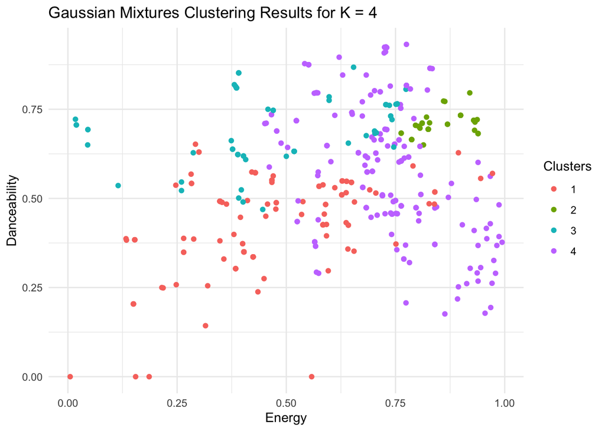

```r
# Add clusters for plotting
X$clusters <- factor(labels)

ggplot(X, aes(x = energy, y = danceability, color = clusters)) +
    geom_point() + theme_minimal() +
    labs(x = "Energy", y = "Danceability",
         title = "Gaussian Mixtures Clustering Results for K = 4",
         color = "Clusters")
```

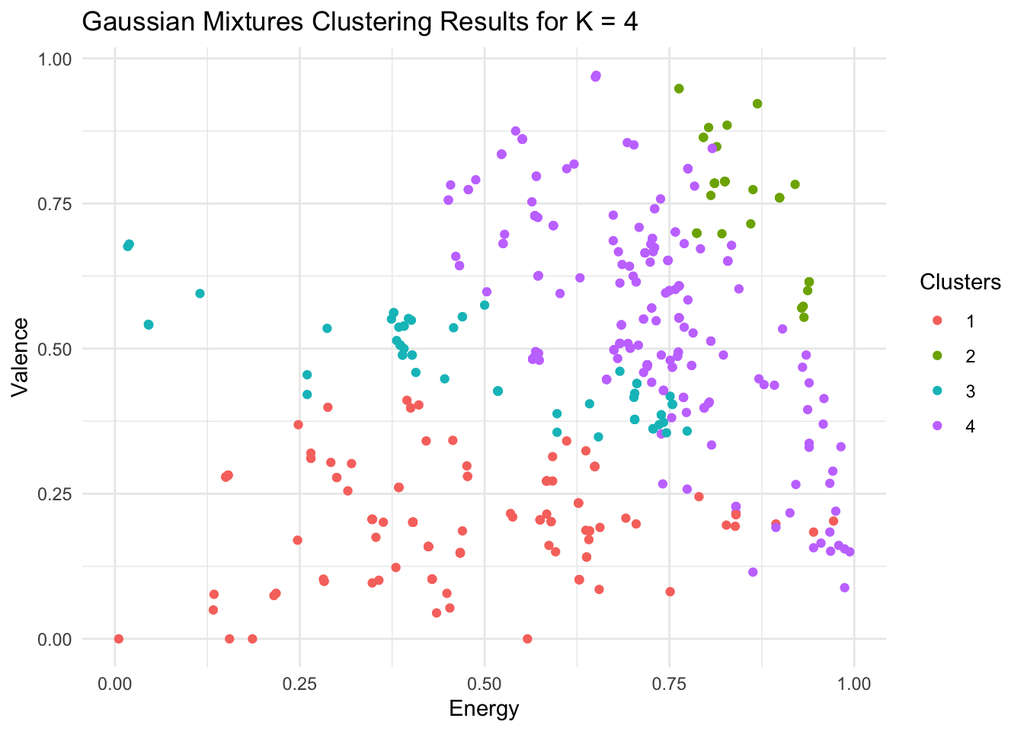

```r
ggplot(X, aes(x = energy, y = valence, color = clusters)) +
    geom_point() + theme_minimal() +
    labs(x = "Energy", y = "Valence",
         title = "Gaussian Mixtures Clustering Results for K = 4",
         color = "Clusters")
```

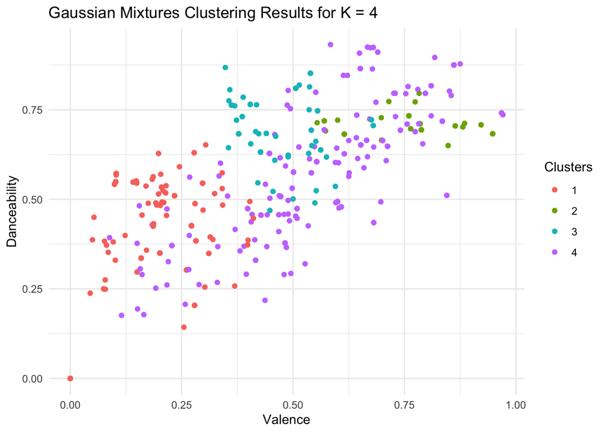

```r
ggplot(X, aes(x = valence, y = danceability, color = clusters)) +
    geom_point() + theme_minimal() +
    labs(x = "Valence", y = "Danceability",
         title = "Gaussian Mixtures Clustering Results for K = 4",
         color = "Clusters")
```

### 1.5.7 BIC

Another measure of cluster performance is the **Bayesian Information Criterion**. The BIC measures how well fit your model is, where **lower** values of BIC are better.

$$BIC = \underbrace{- 2 log(\hat{L})}_\text{goodness of fit} + \underbrace{k*log(N)}_\text{complexity penalty}$$

- $\hat{L}$ is the maximum likelihood of the model ($\prod_{n = 1}^N \sum_{k=1}^K w_k \mathcal{N}(x_n | \mu_k, \Sigma_k)$; from above)
- $N$ is the number of data points
- $k$ is the *number of parameters* in the model (just remember, the more clusters, the more parameters)

When a clustering solution is *good* it’s likelihood will be *high*. So $-2 log(\hat{L})$ will be *low*. BIC also **penalizes complexity** by adding on the $k*log(N)$ term. The more parameters we have to estimate ($k$) the higher $k*log(N)$ will be, thus BIC *penalizes* models for having a lot of parameters. If adding parameters doesn’t improve the fit of the model (measured by $- 2 log(\hat{L})$), we don’t want them. This is similar to **LASSO** and **Ridge** penalties, where we have to have things “pull their weight” in order for them to be “worth” the penalty.

So in summary, we choose models with lower BIC values.

> Important note: In `mclust`, BIC is defined so that larger (less negative) is better.

### 1.5.8 Another Example

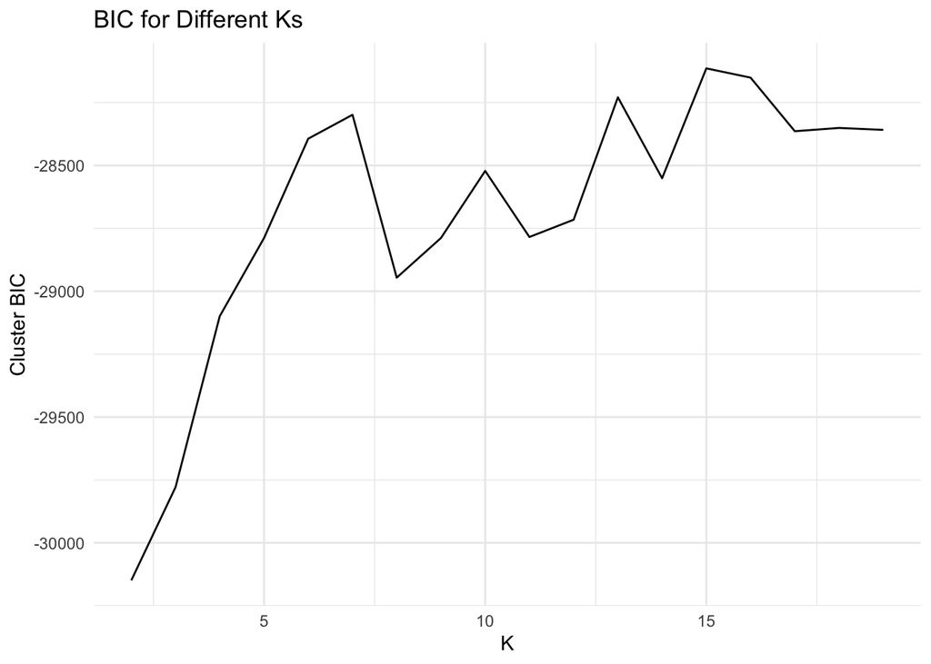

```r
wine <- read.csv(
  "12-data/wineLARGE.csv"
)


# drop NA rows
wine <- na.omit(wine)

# reset row names (similar to reset_index)
rownames(wine) <- NULL

# grab data we want to cluster
feats <- c("citric.acid", "residual.sugar")
X <- wine[, feats]

# StandardScaler equivalent
X_scaled <- scale(X)

# store metrics
metrics <- data.frame(BIC = numeric(), k = integer())

set.seed(123)

for (i in 2:19) {
  gmm <- Mclust(X_scaled, G = i)

  # mclust reports BIC where "higher is better"
  bic_val <- gmm$bic

  metrics <- rbind(metrics, data.frame(BIC = bic_val, k = i))
}

# plot
  ggplot(metrics, aes(x = k, y = BIC)) +
    geom_line() +
    theme_minimal() +
    labs(
      x = "K",
      y = "Cluster BIC",
      title = "BIC for Different Ks"
    )
```

Plot the results:

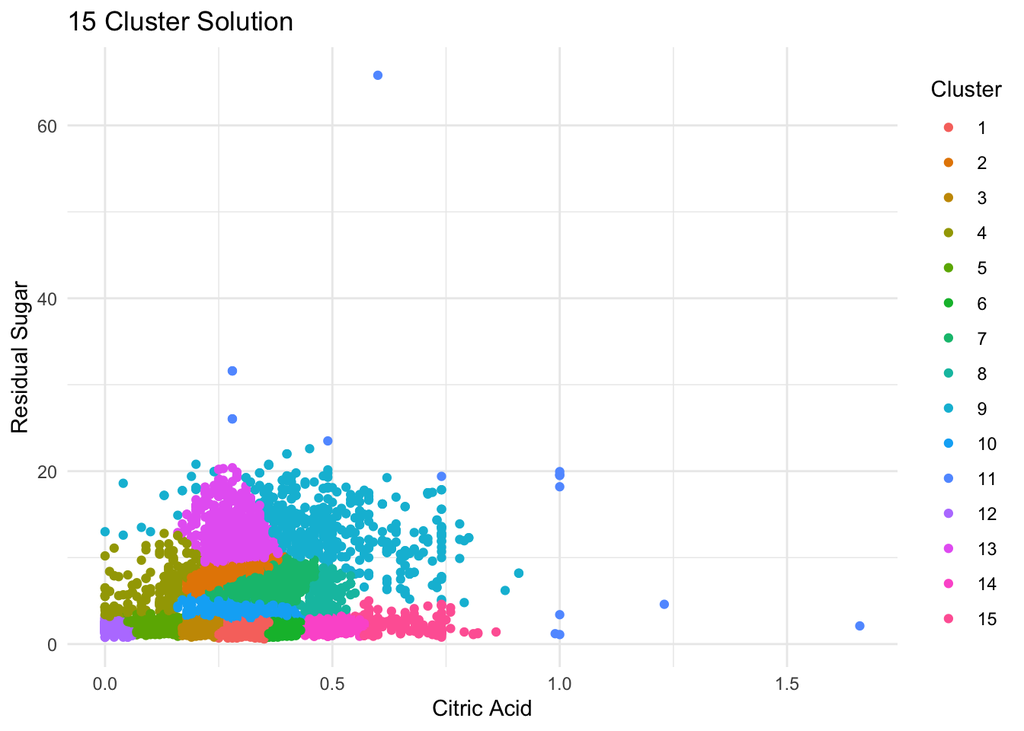

```r
set.seed(123)

# Gaussian Mixture Model with 15 components
gmm <- Mclust(X_scaled, G = 15)

# Cluster labels
labels <- gmm$classification

# Add clusters for plotting
X$cluster <- factor(labels)

ggplot(X, aes(x = citric.acid, y = residual.sugar, color = cluster)) +
    geom_point() +
    theme_minimal() +
    scale_color_discrete(name = "Cluster") +
    labs(
      x = "Citric Acid",
      y = "Residual Sugar",
      title = "15 Cluster Solution"
    )
```

## 1.6 DBSCAN

In general, the algorithm is iterative, starting with a random core point, and finding all the **density connected/reachable** points from that **core point** and putting them into a cluster. Then it moves on to the next point.

If a data point is **noise**, it marks it as such and moves on. This process repeats until all data points have been categorized.

### 1.6.1 Example

```r
library(dbscan) #install
library(cluster)
library(ggplot2)

# read some simulated data
df <- read.csv("12-data/KMEM5.csv")

predictors <- c("x", "y")
X <- df[, predictors]

# StandardScaler equivalent
X_scaled <- scale(X)

# DBSCAN (eps = 0.25, minPts = 15)
db <- dbscan(X_scaled, eps = 0.25, minPts = 15)


labels <- db$cluster  # 0 = noise in R's dbscan

X$clusters <- labels

# Silhouette score (exclude noise points: cluster 0)
keep <- X$clusters != 0
sil <- silhouette(X$clusters[keep], dist(X_scaled[keep, , drop = FALSE]))
mean(sil[, 3])
```

```
[1] 0.7476774
```

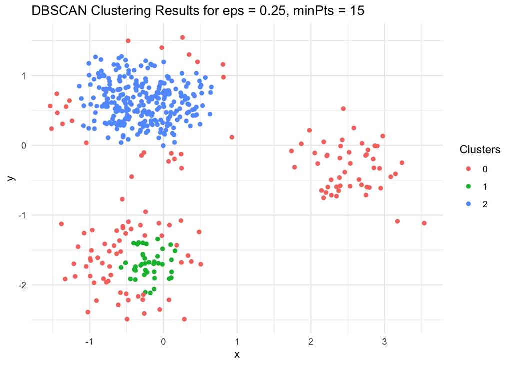

```r
ggplot(X, aes(x = x, y = y, color = factor(clusters))) +
    geom_point() +
    theme_minimal() +
    labs(
      x = "x",
      y = "y",
      title = "DBSCAN Clustering Results for eps = 0.25, minPts = 15",
      color = "Clusters"
    )
```

The DBSCAN results show two dense clusters and a substantial number of points labeled as noise. One large, dense cluster appears in the upper-left region, while a smaller cluster is identified in the lower-left region. Points that do not belong to any sufficiently dense region are labeled as noise (cluster 0), including the scattered points on the right side of the plot. This indicates that DBSCAN successfully identifies clusters of varying shapes while separating outliers based on density.

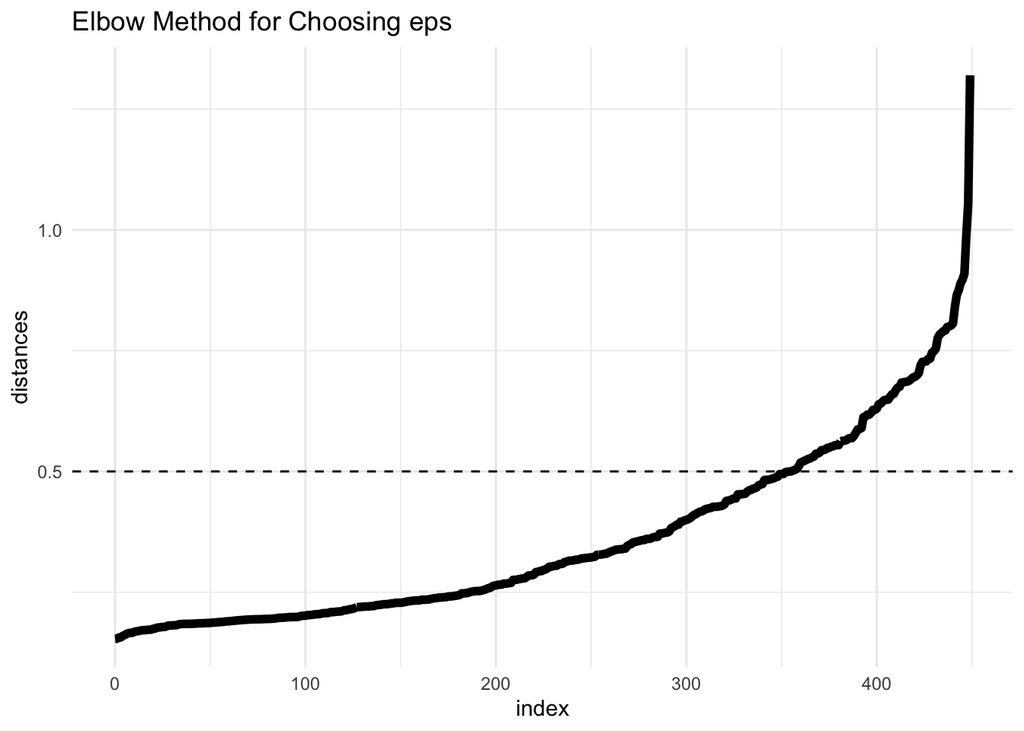

```r
library(FNN)
library(ggplot2)

# we ask for mins + 1 nearest, because the data point itself (distance = 0) is included
mins <- 25
k <- mins + 1

# StandardScaler equivalent (reuse if you already made it above)
X_scaled <- scale(X[, predictors, drop = FALSE])

# get k nearest neighbors for each point
knn_res <- get.knn(X_scaled, k = k)

# distance to the mins-th neighbor (because first neighbor is itself at distance 0)
distances <- sort(knn_res$nn.dist[, mins + 1])

# build data frame for plotting
distances_df <- data.frame(
  index = 0:(length(distances) - 1),
  distances = distances
)

# plot the distances (k-distance plot)
plt <- ggplot(distances_df, aes(x = index, y = distances)) +
  geom_line(linewidth = 2) +
  theme_minimal() +
  labs(title = "Elbow Method for Choosing eps") +
  geom_hline(yintercept = 0.5, linetype = "dashed")

plt
```

The k-distance plot shows a clear elbow around a distance of approximately 0.5, where the curve begins to increase more sharply. This point represents the transition from dense regions to sparser points, making it a reasonable choice for the eps parameter in DBSCAN. Selecting eps near 0.5 helps capture the core clusters while avoiding the inclusion of noise points.

```r
db <- dbscan(X_scaled, eps = 0.5, minPts = 25)

labels <- db$cluster  # 0 = noise in R


X$clusters <- labels

# Silhouette score (exclude noise points, since silhouette needs cluster IDs >= 1)
keep <- X$clusters != 0
sil <- silhouette(X$clusters[keep], dist(X_scaled[keep, , drop = FALSE]))
mean(sil[, 3])
```

```
[1] 0.7065351
```

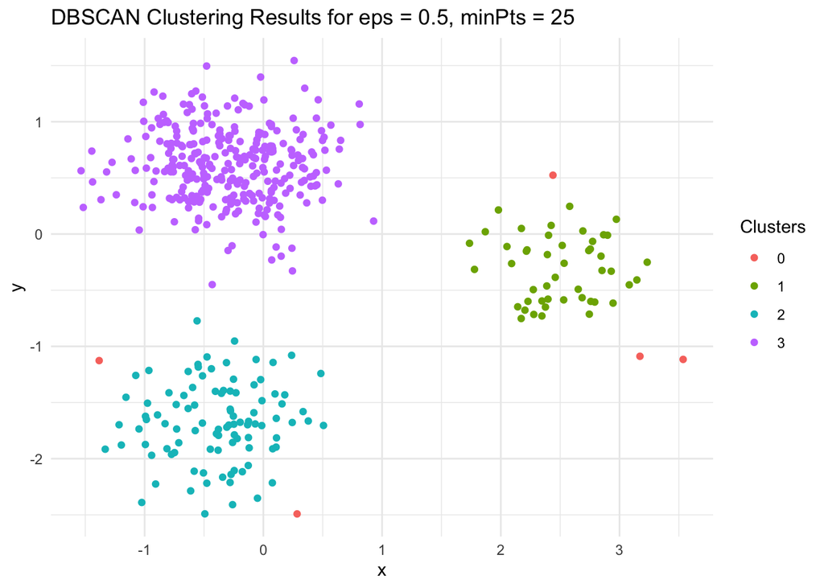

```r
ggplot(X, aes(x = x, y = y, color = factor(clusters))) +
    geom_point() +
    theme_minimal() +
    labs(
      x = "x",
      y = "y",
      title = "DBSCAN Clustering Results for eps = 0.5, minPts = 25",
      color = "Clusters"
    )
```

With eps set to 0.5 and minPts equal to 25, DBSCAN identifies three well-defined clusters and a small number of noise points. Compared to the smaller eps value, the clusters are larger and more cohesive, as nearby dense regions are now connected into single clusters. Only a few isolated points remain labeled as noise, indicating that this parameter choice effectively captures the main structure of the data while minimizing over-fragmentation.